# CDF and Quantile Confidence intervals.

## Introduction

As we all know, empirical CDFs and quantiles derived from data can be very uncertain, especially for small sample sizes. Here is an example using three draws from a standard normal distribution.

```r
set.seed(867-5309)
x1 <- rnorm(50)
x2 <- rnorm(50)
x3 <- rnorm(50)
sapply(list(x1,x2,x3), quantile)
```

```
           [,1]       [,2]        [,3]
0%   -1.6988045 -1.7428518 -2.38447666
25%  -0.8674238 -0.6922447 -0.77395282
50%  -0.4631611 -0.2053935 -0.08830643
75%   0.4739382  0.5185619  0.62052670
100%  1.9355961  2.4091912  2.14253611
```

```r
plot(ecdf(x1), verticals=TRUE, pch='.', col='red')
plot(ecdf(x2), verticals=TRUE, pch='.', col='blue', add=TRUE)
```

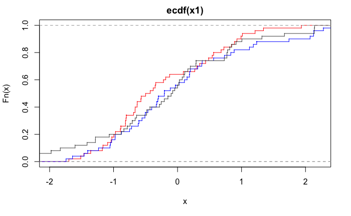

```r
plot(ecdf(x3), verticals=TRUE, pch='.', col='grey30', add=TRUE)
```

If the sample that produced a median estimate of -0.46 doesn’t worry you, it should.

In order to be sure that our results are meaningful, we need to compute confidence intervals on these outputs so that we know how much they might vary from the particular values we happened to get from whatever data we were looking at.

## Empirical CDF Confidence intervals

The first thing to know is that ECDF confidence intervals come in two flavors. *Simultaneous* confidence intervals seek to cover the entire CDF with a specified probability. That is, if you estimate a 95% simultaneous confidence interval, then 95% of the time it will encompass the entire CDF. This is a fairly strong guarantee, and it leads to correspondingly wide confidence intervals. *Pointwise* confidence intervals seek to cover each point with the specified probability. This is a much weaker guarantee. If you compute a 95% pointwise confidence interval, then the CI will have a 95% chance of covering each point on the CDF, but there is a high probability that some (roughly 5%) of the CDF points will lie outside their confidence intervals. This weaker guarantee leads to much tighter confidence intervals than you get with the simultaneous intervals.

The second thing to know is that ECDF confidence intervals are confidence intervals on the distribution function $F(x)$. That is, if $F(x) = p$, your confidence interval is going to be expressed as something like $F(x) = p \pm \varepsilon$. Graphically, this can be expressed as an error envelope that follows the graph of the CDF *above* and *below* the estimator curve. This is important because what we often want is confidence intervals on the Quantile function $Q = F^{-1}(p)$, which would look like an envelope that follows the graph of the CDF to the *left* and *right* of the estimator curve. Although the CDF confidence intervals *imply* such a curve, they don’t give it to us directly.

### Simultaneous confidence intervals with the DKW inequality

The Dvoretzky–Kiefer–Wolfowitz inequality places probabilistic limits on the Kolmogorov-Smirnov statistic (i.e., the statistic that would be used in a K-S test between the ECDF and the true CDF) Let $F_n$ be the empirical CDF, and $F$ be the (unknown) true CDF. The K-S statistic is
$$D = \sup|F_n(x) - F(x)|.$$
The DKW inequality tells us that for $n$ samples
$$P(D > \varepsilon) \leq 2 e^{-2n\varepsilon^2}$$
for any $\varepsilon > 0$. We can convert this into a confidence interval by selecting a confidence level $\alpha$, setting $P(D>\varepsilon)$, and solving for $\varepsilon$. When we do that, we get
$$\varepsilon = \sqrt{\frac{\ln\sqrt{\frac{2}{\alpha}}}{n}}$$
The true CDF then lies (entirely) between the curve $F(x) + \varepsilon$ and $F(x) - \varepsilon$ with probability $1-\alpha$. The most important features of this expression are that $\varepsilon$ scales as $1/\sqrt{n}$ and that it is independent of $x$.

For our `x1` dataset, $n=50$, so we can calculate $\varepsilon$ for a 95% confidence interval as

```r
n <- 50
alpha <- 0.05
eps <- sqrt(log(sqrt(2/alpha))/n)
eps
```

```
[1] 0.1920646
```

This is very large. It means that if $F_n(x) = 0.1$ (i.e., where the CDF crosses the 10th percentile), the value of the *true* CDF could be as high as 0.29, and there is *no* value that could be ruled out on the low end. The situation improves with a larger dataset, but only slowly. If we were to double the size of the dataset, our $\varepsilon$ would decrease to 0.1358102.

### Pointwise confidence intervals

Pointwise confidence intervals are based on the binomial distribution. The idea is that if we are saying $F_n(x) = p$, what we really mean is that in $n$ observations we saw $k$ values less than $x$, and $p = k/n$. That value of $p$ is the maximum likelihood estimator for the true value of $F(x)$, but the actual probability distribution for $F(x)$ is a beta distribution
$$F(x) \sim B(k+1, n-k+1)$$
This is almost the same as the distribution used in the Jeffreys Interval, which replaces $k+1$ and $n-k+1$ with $k+\frac{1}{2}$ and $n-k+\frac{1}{2}$. Both are Bayesian estimates, starting with slightly different priors. The difference is too small to be concerned about.

Getting a confidence interval from this distribution is conceptually straightforward. Here are the 95% confidence intervals for $F_n(x)$ at the 10th percentile value of $x$.

```r
n <- 50
q <- 0.1
k <- floor(n*q)
ci <- qbeta(c(0.025, 1-0.025), k+1, n-k+1)
ci
```

```
[1] 0.04442014 0.21414498
```

So, the true CDF at our alleged 10th percentile value could be as low as 0.0444201 or as high as 0.214145. Still very imprecise, but a bit tighter than what we got with the DKW inequality.

Because there isn’t a closed-form solution for this confidence interval, it’s a little hard to assess how it scales with more data. For datasets with more than a few dozen or so data points this calculation can be reasonably well approximated with the equivalent expression from an approximation using a normal distribution. In this approximation, $F(x) = F_n(x) \pm \varepsilon$, where
$$\varepsilon = z\sqrt{\frac{\hat{p}(1-\hat{p})}{n}},$$
where $\hat{p} = F_n(x) = k/n$ is the estimate of the CDF, and $z$ is the z-score in a standard normal distribution for the desired value of $\alpha$. For a 95% confidence interval, $\alpha = 0.05$, and $z = 1.96$. Comparing to the calculation using the Beta distribution, if $\hat{p} = 0.1$

```r
n <- 50
q <- 0.1
epsnorm <- 1.96 * sqrt(q*(1-q)/n)
cinorm <- q + c(-epsnorm, epsnorm)
cinorm
```

```
[1] 0.01684424 0.18315576
```

The width of this interval is about the same as the one derived from the Beta distribution, but it’s shifted a bit to the lower end. I prefer to use the more exact expression, but one thing the approximation does is to allow us to see how this expression depends on the data. As with the DKW formula, $\varepsilon$ decreases with the square root of $n$. Unlike DKW, this one is not constant for all $x$. Instead, it is proportional to $\sqrt{F_n(x) (1-F_n(x))}$. Thus, the bounds actually get tighter in absolute terms as you move to the tails of the distribution. This is the equivalent of saying that if a value is the highest or lowest value in a dataset, you can be fairly confident that such values are uncommon (where “common” is relative to the number of observations). On the other hand, if a value appears near the middle of the dataset, it’s likely to be a common result, but it’s hard to say just where within the central core of the distribution it lies.

## Quantile confidence intervals

As we remarked above, when we draw the ECDF confidence intervals, it implies something about the confidence intervals for the quantile function, but it doesn’t allow us to calculate them directly. Actually doing this calculation is a little bit tricky, but I found some good material on the subject at [Cross Validated](https://stats.stackexchange.com/a/284970) and in a [blog post](http://staff.math.su.se/hoehle/blog/2016/10/23/quantileCI.html) written by a math professor at Stockholm University.

Let’s start by computing the *order statistics*, which is nothing more than a fancy way of saying, let’s sort the observed values from smallest to largest.

```r
n <- length(x1)
x1r <- sort(x1)
cat(paste(signif(x1r[1:10], 3), collapse=', '), '...')
```

```
-1.7, -1.51, -1.46, -1.36, -1.18, -1.17, -1.09, -1.04, -1.03, -0.995 ...
```

Next, we’ll select a quantile value that we want to obtain a confidence interval for. For this example we’ll use $q = 0.1$, the 10th percentile. The question we’ll ask is, for each of these observations, if we *assume* that it is the true 10th percentile, what is the probability that it wound up in the position it did. For example, the lowest value is $x_1 =$ -1.7. In order for it to have wound up as the lowest value, each draw had wind up greater than $x_1$. *If* $x_1$ were the true 10th percentile value, the probability of this happening on each draw would be 0.9, and the probability of it happening on all 49 subsequent draws would be 0.0057264, which is pretty small, but not inconceivable. We can do the same exercise for $x_2$; it had to have exactly 1 draw that wound up less, with a probability of 0.0311772, and we can continue down the line. (Note, by the way, that I am using $n-1$ in the expression for the binomial distribution, rather than $n$, as in the sources I cited. I believe that $n-1$ is the correct way to do it, but the difference is small in any case.) When you’re finished, you have a discrete probability distribution where each of the discrete values is the probability that *that* value would have wound up in its order position, had it in fact been the 10th percentile of the (unknown) true distribution. With a few technical assumptions (see the sources above for elaboration), we can restate this as the probability for each of our observed values that *it* is the true 10th percentile of the distribution.

All that remains now is to choose a confidence interval such that the sum of these probabilities over the confidence interval is greater than or equal to our chosen confidence level (95%, as is tradition). We have to say “greater than or equal” rather than “equal” because with a discrete distribution there may not be any values avalialble that make the sum *exactly* equal to our confidence level. The easiest way to find this is to use `qbinom` (see the Stockholm University post for other ways)

```r
qci <- function(p, n, data=NULL, alpha=0.05) {
    ## We have to add 1 to k1 and k2 because x1r[1] holds k==0, x1r[2] holds k==1, etc.
    k1 <- floor(qbinom(alpha/2, n-1, p)) + 1
    k2 <- ceiling(qbinom(1-alpha/2, n-1, p)) + 1
    qvals <- c(k1, k2)       # These are the order stats that give the confidence intervals
    if(is.null(data)) {
        xvals <- c(0,0)
    }
    else {
        xvals <- signif(data[c(k1,k2)],3)      # These are the actual x values in the confidence intervals
    }
    list(qvals=qvals, xvals=xvals, ciwidth=xvals[2]-xvals[1])
}
qci(0.1, 50, x1r)
```

```
$qvals
[1]  2 10

$xvals
[1] -1.510 -0.995

$ciwidth
[1] 0.515
```

The point estimate of the 10th percentile was -1.17, so this is a moderately large uncertainty. Incidentally, if you plug these confidence boundaries into the ECDF function for `x1` you get 0.04, 0.2, which is very close to our estimate of the confidence intervals for $F_n(x)$ at the point where it crossed the 10th percentile, so this all seems consistent.

This one is another case where it isn’t so easy to figure out what the effect of an increasing data set size might be, and I couldn’t find a handy approximation that would allow us to figure this out, so I had to fall back on some simulation. First note that the width of the confidence interval is determined by both the shape of the binomial distribution (which depends on $n$ and $q$) and the shape of the ECDF (a shallower CDF produces a larger uncertainty). The former helps us in the tails and hurts us in the core; for the latter it’s the opposite.

We’ll try looking at a few confidence intervals for the 25th and 50th percentiles to see how the choice of quantile affects our uncertainty, and then we’ll try looking at larger sample sizes.

```r
cat('p=0.25\n')
```

```
p=0.25
```

```r
qci(0.25, 50, x1r)
```

```
$qvals
[1]  8 19

$xvals
[1] -1.040 -0.664

$ciwidth
[1] 0.376
```

```r
cat('p=0.5\n')
```

```
p=0.5
```

```r
qci(0.5, 50, x1r)
```

```
$qvals
[1] 19 32

$xvals
[1] -0.664 -0.124

$ciwidth
[1] 0.54
```

The trend here is obscured a bit by discreteness effects. Here is the whole curve from 0.01 to 0.5

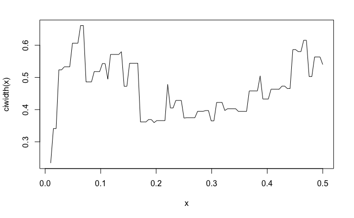

```r
ciwidth <- function(x) {
    alpha <- 0.05
    k1 <- floor(qbinom(alpha/2, n-1, x))+1
    k2 <- ceiling(qbinom(1-alpha/2, n-1, x))+1
    x1r[k2]-x1r[k1]
}
curve(ciwidth, from=0.01, to=0.5)
```

It’s hard to tell if there is any real trend here. Probably the specifics of the ECDF are the driving force here.

We can do a similar experiment keeping the quantile fixed at 0.1 and varying the number of data points.

```r
x100 <- sort(rnorm(100))
x150 <- sort(rnorm(150))  # Longest data set we think we can get
x400 <- sort(rnorm(400))
```

```r
cat('n=100\n')
```

```
n=100
```

```r
qci(0.1, 100, x100)
```

```
$qvals
[1]  5 17

$xvals
[1] -1.580 -0.962

$ciwidth
[1] 0.618
```

```r
cat('n=150\n')
```

```
n=150
```

```r
qci(0.1, 150, x150)
```

```
$qvals
[1]  9 23

$xvals
[1] -1.4 -1.0

$ciwidth
[1] 0.4
```

```r
cat('n=400\n')
```

```
n=400
```

```r
qci(0.1, 400, x400)
```

```
$qvals
[1] 30 53

$xvals
[1] -1.36 -1.12

$ciwidth
[1] 0.24
```

It looks plausible that this might be decreasing as $1/\sqrt{n}$, but it’s hard to say for sure.

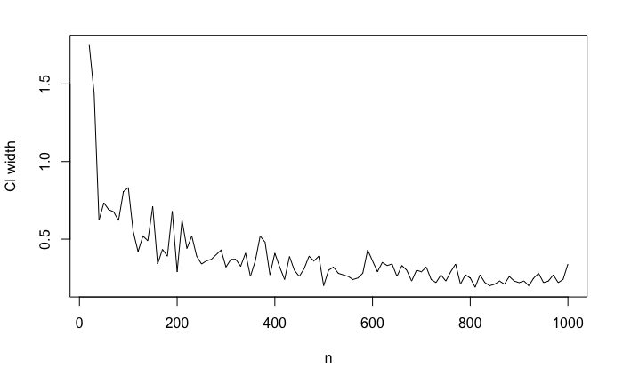

```r
ciwn <- function(n) {
    simd <- sort(rnorm(n))
    qci(0.1, n, simd)$ciwidth
}
x <- seq(20, 1000, 10)
y <- sapply(x, ciwn)
plot(x,y, type='l', xlab = 'n', ylab='CI width')
```

I think the main thing we can say here is that the improvement assuredly no *better* than $1/\sqrt{n}$.

## What does this mean for our threshold procedure?

Upon further review, here’s what I think we really care about in our threshold. If we select a threshold by picking, say, the 10th percentile, then if we look at another dataset with the same distribution (e.g., another run over the historical period, if such a thing were available), we would want about 10% of the values to fall below the threshold. We’d be ok with it if the actual number were something like 8-12%, but 0% or 20% would be wholly unacceptable. Note that we *don’t* actually care what the interval for the corresponding $x$ values is.  
Therefore, we need a sample large enough that the expected error *expressed as a difference in quantile* is less than, say, 0.02.

I’m half-convinced that this is equivalent to saying that the CI on $F_n(x)$ should be less than our desired precision, but let’s grind it out with our quantile formula and see if that method agrees.

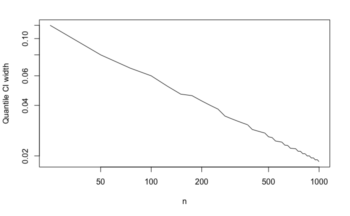

```r
quantbnd <- function(n) {
    qv <- qci(0.1, n)$qvals / n  # Given the k values from the calc, k/n is the quantile estimate
    0.5*(qv[2]-qv[1])
}
x <- seq(25,1000,25)
y <- sapply(x, quantbnd)
plot(x,y, type='l', xlab='n', ylab='Quantile CI width', log='xy')
```

That looks like $1/\sqrt{n}$ behavior to me. What’s more, recall the normal approximation to the pointwise confidence interval for $F_n$:
$$\varepsilon = z\sqrt{\frac{\hat{p}(1-\hat{p})}{n}}.$$
What does this predict for $n$ if we want $\varepsilon = 0.02$? For a 95% confidence interval, $z \approx 2$, and we can solve this equation for $n$.
$$n = 10^4 \hat{p}(1-\hat{p})$$
For $\hat{p} = 0.1$, this comes out to 900, which is right about where the curve above crosses $y = 0.02$.

## Conclusion

So, we’ve come the long way around the barn, but I think we have learned a lot on the trip. We now know how to do both simultaneous and pointwise confidence intervals for CDFs. Perhaps surprisingly, when expressed as a function of $p$, these don’t depend on the details of the CDF, though if you want to get them in terms of the input $x$ values, then obviously they do. We also learned how to get confidence intervals for quantiles in terms of the $x$ values, so we can say, for example, that the 10th percentile of the `x1` distribution is -1.17 with a 95% confidence interval of (-1.51, -0.995).

To our original purpose, what we really want to know is, when we estimate a quantile from our data, how far off, in terms of quantiles, might it be? That is, might our estimate of the 10th percentile *actually* be the 5th, or the 20th percentile in the real distribution? That sounds like a question about confidence intervals on the quantile estimate, but it’s really not; it’s a question about confidence intervals on the CDF, but with its inputs expressed as quantile values rather than $x$ values. As we saw above, when expressed that way the dependence on the details of the CDF all cancels out, and we can derive a completely general result. For desired accuracy (95% confidence) $\varepsilon$ in quantile $p$, the number of observations you need is
$$n = \left(\frac{\varepsilon}{2}\right)^{-2} p (1-p)$$
With $\varepsilon = 0.02$ and $p = 0.1$, that works out to about 900. Our current dataset has about 50 observations, and *if* we could track down bias corrected ESM runs going back to 1860, that would boost us up to $\varepsilon \approx 0.05$, which might be just barely acceptable. On the other hand, 20 fldgen runs trained on the historical data set would almost certainly do the trick.